# MSBI 32000 Winter 2022

Final Project

# Introdution

Before the development of effective chemotherapy for colon cancer, treatment was limited to surgery. Recurrence was frequent and life-expectancy after initial treatment was not long.

However, from 1985 to 1990, adjuvant chemotherapy began to be developed and implemented in combination with surgery.

After simultaneous advancements in detection and screening, death rates due to colon cancer began to fall: a 54% reduction.

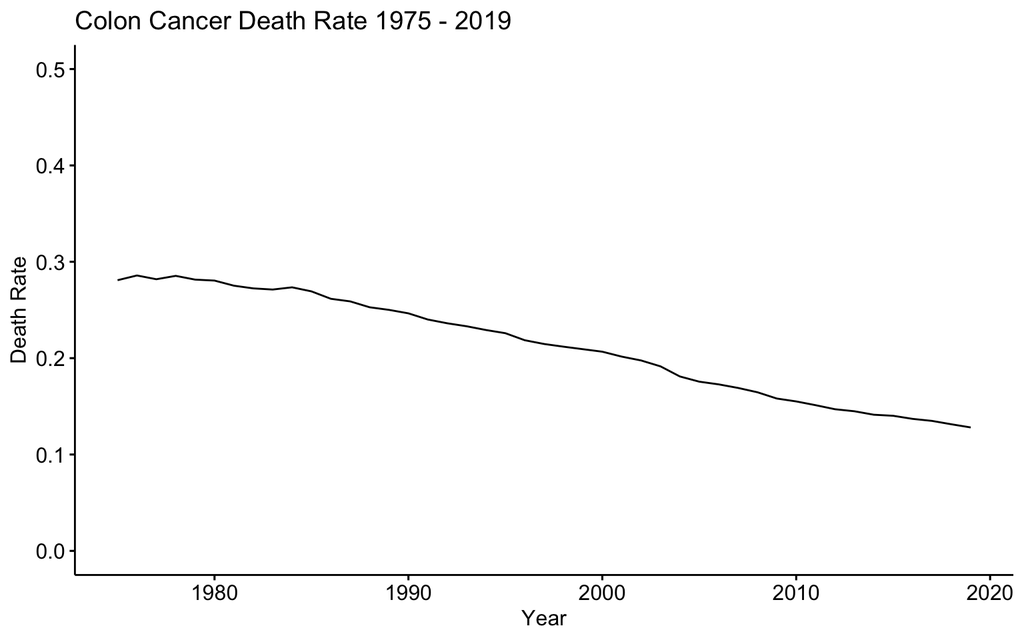

```r
library(ggpubr)
# Colon Cancer death rate in the US over time.
cancerData <- read.table("ColonCancerDeathRate.txt", header=TRUE)
cancerData$Prop <- cancerData$Prop / 100
g <- ggline(cancerData, x="Year", y="Prop",
       plot_type="l",
       title="Colon Cancer Death Rate 1975 - 2019",
       xlab="Year",
       ylab="Death Rate")
ggpar(g, ylim=c(0,0.50))
```

Today, excluding skin cancer, colon cancer is the third most common type of cancer in the U.S., but there are now more treatments available, including immunotherapy and radiation therapy. In this study, we will examine the outcomes of a clinical Colon Cancer study that measured the effects of two treatment groups and a control.

# Data Source

This data set comes from one of the first successful trials of adjuvant chemotherapy for colon cancer, using a combination of levamisole and fluorouracil.

The trial examined both Stage B2 (locally invasive) and Stage C (regional nodal involvement) colon cancer, but this dataset contains information only on subjects with Stage C.

The data set had a complicated format. For each subject, there were two rows of data entry: one measuring data related to the first recurrence of cancer, such as days until recurrence, and the other measuring data related to death, such as presence of cancer in other regions. The rows were categorized by the “etype” nominal variable, which we used to sort the data.

In addition, each row had a “status” nominal variable, that indicated whether the etype was positive or negative – whether there was or was not recurrence, and whether or not the subject had died. This required additional sorting of the data.

Each subject in the study was assigned a treatment – observation, levamisole (alone), or levamisole and fluorouracil (combined) – and this was recorded by the “rx” nominal variable for each row of data, allowing us to sort, analyze, and compare the effectiveness of the different treatments.

## Import Data

The below code imports the data sets. Click show to view it.

```r
colonData <- read.table("colon.txt", header = TRUE)

# Grabs Recurrence Data from colonData
studyA <- subset(colonData, etype==1)

# Grabs Death Data from colonData
studyB <- subset(colonData, etype==2)

# Add year column
studyA$years <- studyA$time / 365.25
studyB$years <- studyB$time / 365.25

# Treatment groups
obsA <- subset(studyA, rx=="Obs")
levA <- subset(studyA, rx=="Lev")
combA <- subset(studyA, rx=="Lev+5FU")

obsB <- subset(studyB, rx=="Obs")
levB <- subset(studyB, rx=="Lev")
combB <- subset(studyB, rx=="Lev+5FU")

# Convert treatment to number
studyA$xnum <- studyA$rx
studyB$xnum <- studyB$rx

studyA$xnum[studyA$xnum == "Obs"] <- 0
studyA$xnum[studyA$xnum == "Lev"] <- 1
studyA$xnum[studyA$xnum == "Lev+5FU"] <- 2

studyB$xnum[studyB$xnum == "Obs"] <- 0
studyB$xnum[studyB$xnum == "Lev"] <- 1
studyB$xnum[studyB$xnum == "Lev+5FU"] <- 2
```

# Description of Variables

Mean statistics per variable by treatment.

```r
library(gtsummary)
trialA <- studyA %>% select(!c(id, xnum, differ, time, etype))
trialA %>%
  tbl_summary(by = rx) %>%
  modify_caption("Table 1. Reoccurance by Treatment")
```

Table 1. Reoccurance by Treatment

| **Characteristic** | **Lev**, N = 310<sup>1</sup> | **Lev+5FU**, N = 304<sup>1</sup> | **Obs**, N = 315<sup>1</sup> |
| --- | --- | --- | --- |
| study | 310 (100%) | 304 (100%) | 315 (100%) |
| sex | 177 (57%) | 141 (46%) | 166 (53%) |
| age | 61 (53, 69) | 62 (52, 70) | 60 (53, 68) |
| obstruct | 63 (20%) | 54 (18%) | 63 (20%) |
| perfor | 10 (3.2%) | 8 (2.6%) | 9 (2.9%) |
| adhere | 49 (16%) | 39 (13%) | 47 (15%) |
| nodes | 2 (1, 5) | 2 (1, 4) | 2 (1, 5) |
| Unknown | 6 | 9 | 3 |
| status | 172 (55%) | 119 (39%) | 177 (56%) |
| extent |  |  |  |
| 1 | 3 (1.0%) | 10 (3.3%) | 8 (2.5%) |
| 2 | 36 (12%) | 32 (11%) | 38 (12%) |
| 3 | 259 (84%) | 251 (83%) | 249 (79%) |
| 4 | 12 (3.9%) | 11 (3.6%) | 20 (6.3%) |
| surg | 80 (26%) | 76 (25%) | 91 (29%) |
| node4 | 89 (29%) | 79 (26%) | 87 (28%) |
| years | 2.81 (0.91, 6.22) | 5.56 (1.48, 6.64) | 2.89 (0.85, 6.02) |

<sup>1</sup> n (%); Median (IQR)

```r
library(gtsummary)
trialB <- studyB %>% select(!c(id, xnum, differ, time, etype))
trialB %>%
  tbl_summary(by = rx) %>%
  modify_caption("Table 2. Death by Treatment")
```

Table 2. Death by Treatment

| **Characteristic** | **Lev**, N = 310<sup>1</sup> | **Lev+5FU**, N = 304<sup>1</sup> | **Obs**, N = 315<sup>1</sup> |
| --- | --- | --- | --- |
| study | 310 (100%) | 304 (100%) | 315 (100%) |
| sex | 177 (57%) | 141 (46%) | 166 (53%) |
| age | 61 (53, 69) | 62 (52, 70) | 60 (53, 68) |
| obstruct | 63 (20%) | 54 (18%) | 63 (20%) |
| perfor | 10 (3.2%) | 8 (2.6%) | 9 (2.9%) |
| adhere | 49 (16%) | 39 (13%) | 47 (15%) |
| nodes | 2 (1, 5) | 2 (1, 4) | 2 (1, 5) |
| Unknown | 6 | 9 | 3 |
| status | 161 (52%) | 123 (40%) | 168 (53%) |
| extent |  |  |  |
| 1 | 3 (1.0%) | 10 (3.3%) | 8 (2.5%) |
| 2 | 36 (12%) | 32 (11%) | 38 (12%) |
| 3 | 259 (84%) | 251 (83%) | 249 (79%) |
| 4 | 12 (3.9%) | 11 (3.6%) | 20 (6.3%) |
| surg | 80 (26%) | 76 (25%) | 91 (29%) |
| node4 | 89 (29%) | 79 (26%) | 87 (28%) |
| years | 5.15 (2.07, 6.50) | 5.75 (2.71, 6.74) | 5.08 (2.08, 6.21) |

<sup>1</sup> n (%); Median (IQR)

## Extent of Local Cancer Spread

The nominal variable “extent”, which recorded whether the cancer had spread to specific nearby regions, was not affected by treatment:

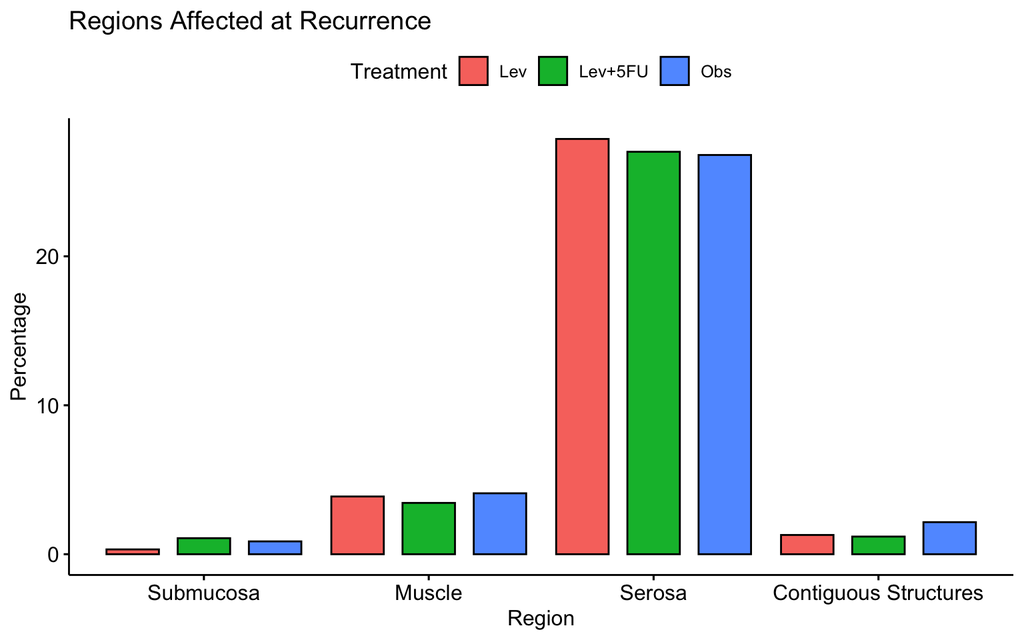

```r
library(ggpubr)
submucosaAobs <- sum(studyA["rx"] == "Obs" & studyA["extent"] == "1")*100/sum(studyA$study==1)
submucosaAlev <- sum(studyA["rx"] == "Lev" & studyA["extent"] == "1")*100/sum(studyA$study==1)
submucosaAlev5FU <- sum(studyA["rx"] == "Lev+5FU" & studyA["extent"] == "1")*100/sum(studyA$study==1)
muscleAobs <- sum(studyA["rx"] == "Obs" & studyA["extent"] == "2")*100/sum(studyA$study==1)
muscleAlev <- sum(studyA["rx"] == "Lev" & studyA["extent"] == "2")*100/sum(studyA$study==1)
muscleAlev5FU <- sum(studyA["rx"] == "Lev+5FU" & studyA["extent"] == "2")*100/sum(studyA$study==1)
serosaAobs <- sum(studyA["rx"] == "Obs" & studyA["extent"] == "3")*100/sum(studyA$study==1)
serosaAlev <- sum(studyA["rx"] == "Lev" & studyA["extent"] == "3")*100/sum(studyA$study==1)
serosaAlev5FU <- sum(studyA["rx"] == "Lev+5FU" & studyA["extent"] == "3")*100/sum(studyA$study==1)
contiguousAobs <- sum(studyA["rx"] == "Obs" & studyA["extent"] == "4")*100/sum(studyA$study==1)
contiguousAlev <- sum(studyA["rx"] == "Lev" & studyA["extent"] == "4")*100/sum(studyA$study==1)
contiguousAlev5FU <- sum(studyA["rx"] == "Lev+5FU" & studyA["extent"] == "4")*100/sum(studyA$study==1)
extentdf <- data.frame(Region = rep(c("Submucosa", "Muscle", "Serosa", "Contiguous Structures"), each=3),
                       Treatment = rep(c("Obs", "Lev", "Lev+5FU"),4),
                       Percentage = c(submucosaAobs, submucosaAlev, submucosaAlev5FU,
                                      muscleAobs, muscleAlev, muscleAlev5FU,
                                      serosaAobs, serosaAlev, serosaAlev5FU,
                                      contiguousAobs, contiguousAlev, contiguousAlev5FU))
ggbarplot(extentdf, "Region", "Percentage", fill="Treatment", position=position_dodge(), title = "Regions Affected at Recurrence")
```

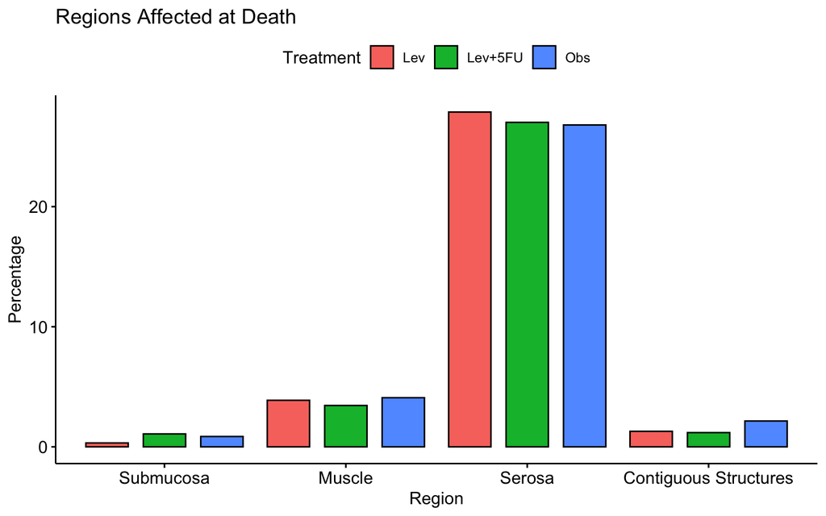

```r
submucosaBobs <- sum(studyB["rx"] == "Obs" & studyB["extent"] == "1")*100/sum(studyB$study==1)
submucosaBlev <- sum(studyB["rx"] == "Lev" & studyB["extent"] == "1")*100/sum(studyB$study==1)
submucosaBlev5FU <- sum(studyB["rx"] == "Lev+5FU" & studyB["extent"] == "1")*100/sum(studyB$study==1)
muscleBobs <- sum(studyB["rx"] == "Obs" & studyB["extent"] == "2")*100/sum(studyB$study==1)
muscleBlev <- sum(studyB["rx"] == "Lev" & studyB["extent"] == "2")*100/sum(studyB$study==1)
muscleBlev5FU <- sum(studyB["rx"] == "Lev+5FU" & studyB["extent"] == "2")*100/sum(studyB$study==1)
serosaBobs <- sum(studyB["rx"] == "Obs" & studyB["extent"] == "3")*100/sum(studyB$study==1)
serosaBlev <- sum(studyB["rx"] == "Lev" & studyB["extent"] == "3")*100/sum(studyB$study==1)
serosaBlev5FU <- sum(studyB["rx"] == "Lev+5FU" & studyB["extent"] == "3")*100/sum(studyB$study==1)
contiguousBobs <- sum(studyB["rx"] == "Obs" & studyB["extent"] == "4")*100/sum(studyB$study==1)
contiguousBlev <- sum(studyB["rx"] == "Lev" & studyB["extent"] == "4")*100/sum(studyB$study==1)
contiguousBlev5FU <- sum(studyB["rx"] == "Lev+5FU" & studyB["extent"] == "4")*100/sum(studyB$study==1)
extentBdf <- data.frame(Region = rep(c("Submucosa", "Muscle", "Serosa", "Contiguous Structures"), each=3),
                        Treatment = rep(c("Obs", "Lev", "Lev+5FU"),4),
                        Percentage = c(submucosaBobs, submucosaBlev, submucosaBlev5FU, muscleBobs, muscleBlev, muscleBlev5FU,
                                       serosaBobs, serosaBlev, serosaBlev5FU, contiguousBobs, contiguousBlev, contiguousBlev5FU))
ggbarplot(extentBdf, "Region", "Percentage", fill="Treatment", position=position_dodge(), title = "Regions Affected at Death")
```

## Obstruction of Colon by Tumour

The nominal variable “obstruct”, which specified whether the colon was obstructed by the cancerous tumor, was not affected by treatment:

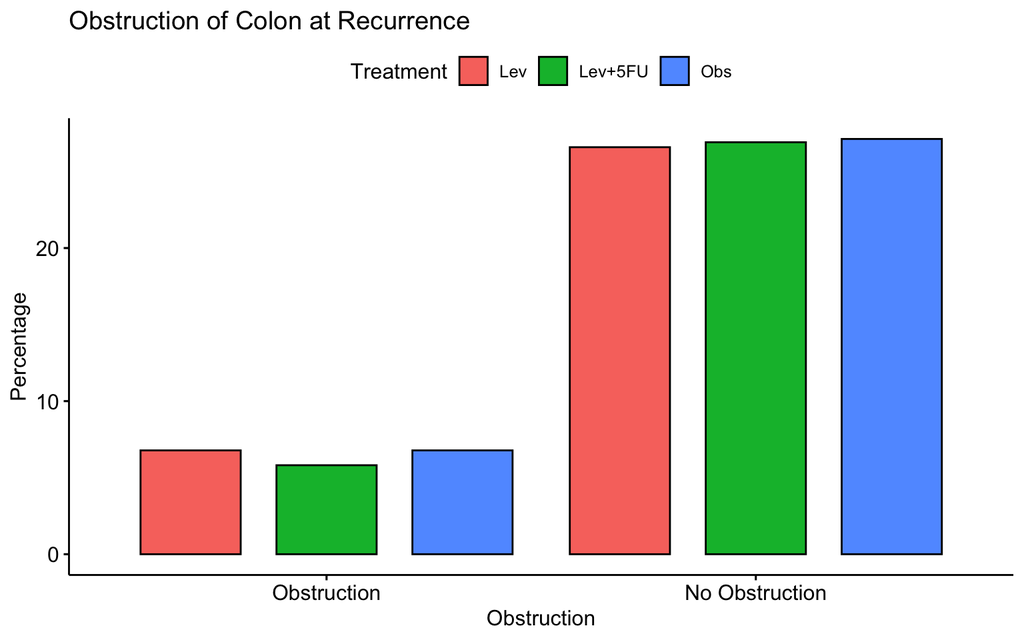

```r
obstructAobs <- sum(studyA["rx"] == "Obs" & studyA["obstruct"] == "1")*100/sum(studyA$study==1)
obstructAlev <- sum(studyA["rx"] == "Lev" & studyA["obstruct"] == "1")*100/sum(studyA$study==1)
obstructAlev5FU <- sum(studyA["rx"] == "Lev+5FU" & studyA["obstruct"] == "1")*100/sum(studyA$study==1)
noobstructAobs <- sum(studyA["rx"] == "Obs" & studyA["obstruct"] == "0")*100/sum(studyA$study==1)
noobstructAlev <- sum(studyA["rx"] == "Lev" & studyA["obstruct"] == "0")*100/sum(studyA$study==1)
noobstructAlev5FU <- sum(studyA["rx"] == "Lev+5FU" & studyA["obstruct"] == "0")*100/sum(studyA$study==1)
obstructAdf <- data.frame(Obstruction = rep(c("Obstruction", "No Obstruction"), each=3),
                          Treatment = rep(c("Obs", "Lev", "Lev+5FU"),2),
                          Percentage = c(obstructAobs, obstructAlev, obstructAlev5FU,
                                         noobstructAobs, noobstructAlev, noobstructAlev5FU))
ggbarplot(obstructAdf, "Obstruction", "Percentage", fill="Treatment", position=position_dodge(), title = "Obstruction of Colon at Recurrence")
```

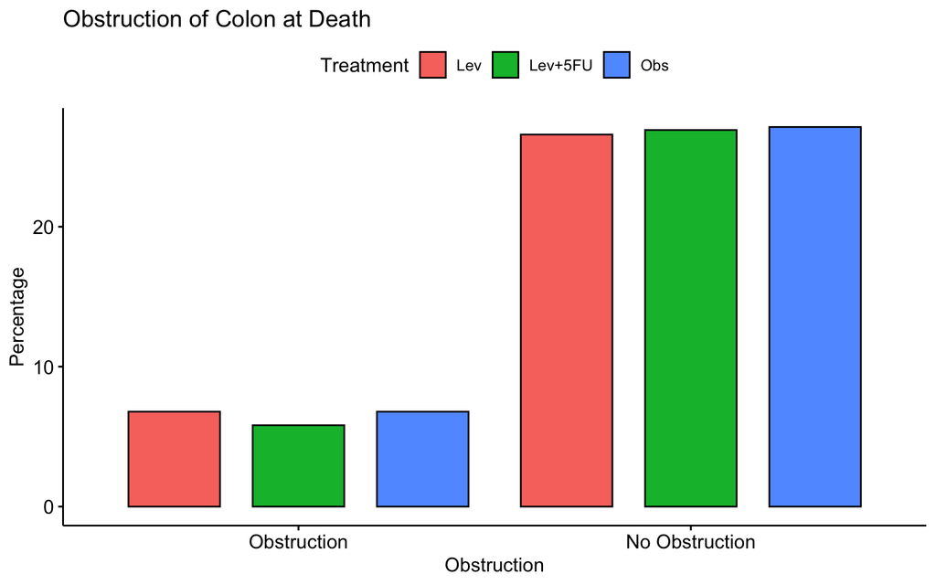

```r
obstructBobs <- sum(studyB["rx"] == "Obs" & studyB["obstruct"] == "1")*100/sum(studyB$study==1)
obstructBlev <- sum(studyB["rx"] == "Lev" & studyB["obstruct"] == "1")*100/sum(studyB$study==1)
obstructBlev5FU <- sum(studyB["rx"] == "Lev+5FU" & studyB["obstruct"] == "1")*100/sum(studyB$study==1)
noobstructBobs <- sum(studyB["rx"] == "Obs" & studyB["obstruct"] == "0")*100/sum(studyB$study==1)
noobstructBlev <- sum(studyB["rx"] == "Lev" & studyB["obstruct"] == "0")*100/sum(studyB$study==1)
noobstructBlev5FU <- sum(studyB["rx"] == "Lev+5FU" & studyB["obstruct"] == "0")*100/sum(studyB$study==1)
obstructBdf <- data.frame(Obstruction = rep(c("Obstruction", "No Obstruction"), each=3),
                          Treatment = rep(c("Obs", "Lev", "Lev+5FU"),2),
                          Percentage = c(obstructBobs, obstructBlev, obstructBlev5FU,
                                         noobstructBobs, noobstructBlev, noobstructBlev5FU))
ggbarplot(obstructBdf, "Obstruction", "Percentage", fill="Treatment", position=position_dodge(), title = "Obstruction of Colon at Death")
```

## Perforation of Colon by Tumour

The nominal variable “perfor”, which specified whether the colon was perforated by the cancerous tumor, was not affected by treatment:

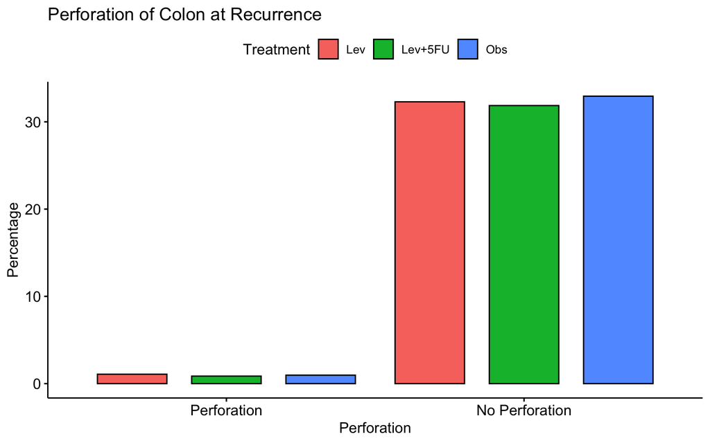

```r
perforAobs <- sum(studyA["rx"] == "Obs" & studyA["perfor"] == "1")*100/sum(studyA$study==1)
perforAlev <- sum(studyA["rx"] == "Lev" & studyA["perfor"] == "1")*100/sum(studyA$study==1)
perforAlev5FU <- sum(studyA["rx"] == "Lev+5FU" & studyA["perfor"] == "1")*100/sum(studyA$study==1)
noperforAobs <- sum(studyA["rx"] == "Obs" & studyA["perfor"] == "0")*100/sum(studyA$study==1)
noperforAlev <- sum(studyA["rx"] == "Lev" & studyA["perfor"] == "0")*100/sum(studyA$study==1)
noperforAlev5FU <- sum(studyA["rx"] == "Lev+5FU" & studyA["perfor"] == "0")*100/sum(studyA$study==1)
perforAdf <- data.frame(Perforation= rep(c("Perforation", "No Perforation"), each=3),
                        Treatment = rep(c("Obs", "Lev", "Lev+5FU"),2),
                        Percentage = c(perforAobs, perforAlev, perforAlev5FU,
                                       noperforAobs, noperforAlev, noperforAlev5FU))
ggbarplot(perforAdf, "Perforation", "Percentage", fill="Treatment", position=position_dodge(), title = "Perforation of Colon at Recurrence")
```

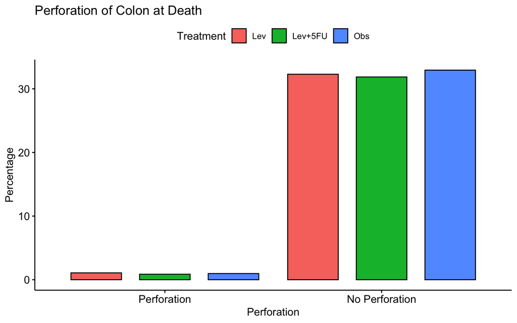

```r
perforBobs <- sum(studyB["rx"] == "Obs" & studyB["perfor"] == "1")*100/sum(studyB$study==1)
perforBlev <- sum(studyB["rx"] == "Lev" & studyB["perfor"] == "1")*100/sum(studyB$study==1)
perforBlev5FU <- sum(studyB["rx"] == "Lev+5FU" & studyB["perfor"] == "1")*100/sum(studyB$study==1)
noperforBobs <- sum(studyB["rx"] == "Obs" & studyB["perfor"] == "0")*100/sum(studyB$study==1)
noperforBlev <- sum(studyB["rx"] == "Lev" & studyB["perfor"] == "0")*100/sum(studyB$study==1)
noperforBlev5FU <- sum(studyB["rx"] == "Lev+5FU" & studyB["perfor"] == "0")*100/sum(studyB$study==1)
perforBdf <- data.frame(Perforation = rep(c("Perforation", "No Perforation"), each=3),
                        Treatment = rep(c("Obs", "Lev", "Lev+5FU"),2),
                        Percentage = c(perforBobs, perforBlev, perforBlev5FU,
                                       noperforBobs, noperforBlev, noperforBlev5FU))
ggbarplot(perforBdf, "Perforation", "Percentage", fill="Treatment", position=position_dodge(), title = "Perforation of Colon at Death")
```

## Adherence of Cancer to Nearby Organs

The nominal variable “adhere”, which specified whether the cancer adhered to nearby organs, was not affected by treatment:

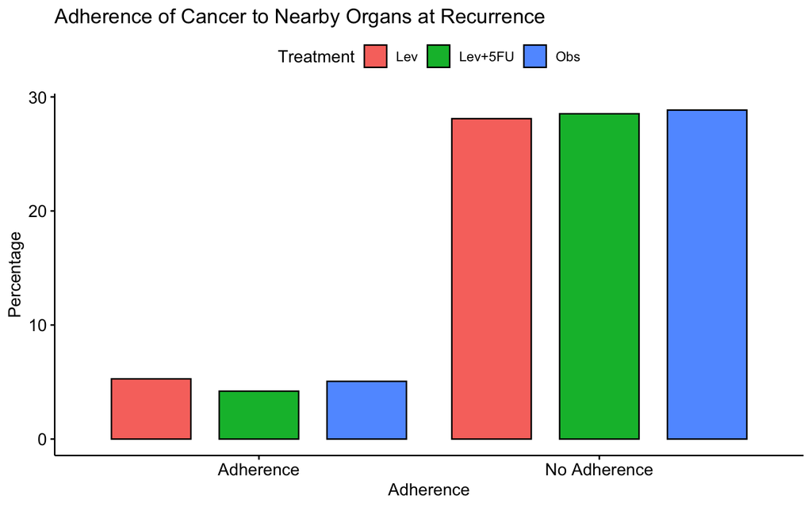

```r
adhereAobs <- sum(studyA["rx"] == "Obs" & studyA["adhere"] == "1")*100/sum(studyA$study==1)
adhereAlev <- sum(studyA["rx"] == "Lev" & studyA["adhere"] == "1")*100/sum(studyA$study==1)
adhereAlev5FU <- sum(studyA["rx"] == "Lev+5FU" & studyA["adhere"] == "1")*100/sum(studyA$study==1)
noadhereAobs <- sum(studyA["rx"] == "Obs" & studyA["adhere"] == "0")*100/sum(studyA$study==1)
noadhereAlev <- sum(studyA["rx"] == "Lev" & studyA["adhere"] == "0")*100/sum(studyA$study==1)
noadhereAlev5FU <- sum(studyA["rx"] == "Lev+5FU" & studyA["adhere"] == "0")*100/sum(studyA$study==1)
adhereAdf <- data.frame(Adherence = rep(c("Adherence", "No Adherence"), each=3),
                        Treatment = rep(c("Obs", "Lev", "Lev+5FU"),2),
                        Percentage = c(adhereAobs, adhereAlev, adhereAlev5FU,
                                       noadhereAobs, noadhereAlev, noadhereAlev5FU))
ggbarplot(adhereAdf, "Adherence", "Percentage", fill="Treatment", position=position_dodge(), title = "Adherence of Cancer to Nearby Organs at Recurrence")
```

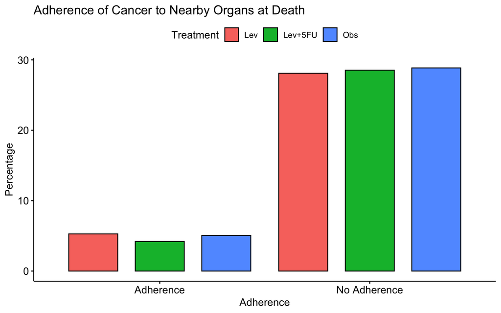

```r
adhereBobs <- sum(studyB["rx"] == "Obs" & studyB["adhere"] == "1")*100/sum(studyB$study==1)
adhereBlev <- sum(studyB["rx"] == "Lev" & studyB["adhere"] == "1")*100/sum(studyB$study==1)
adhereBlev5FU <- sum(studyB["rx"] == "Lev+5FU" & studyB["adhere"] == "1")*100/sum(studyB$study==1)
noadhereBobs <- sum(studyB["rx"] == "Obs" & studyB["adhere"] == "0")*100/sum(studyB$study==1)
noadhereBlev <- sum(studyB["rx"] == "Lev" & studyB["adhere"] == "0")*100/sum(studyB$study==1)
noadhereBlev5FU <- sum(studyB["rx"] == "Lev+5FU" & studyB["adhere"] == "0")*100/sum(studyB$study==1)
adhereBdf <- data.frame(Adherence = rep(c("Adherence", "No Adherence"), each=3),
                        Treatment = rep(c("Obs", "Lev", "Lev+5FU"),2),
                        Percentage = c(adhereBobs, adhereBlev, adhereBlev5FU,
                                       noadhereBobs, noadhereBlev, noadhereBlev5FU))
ggbarplot(adhereBdf, "Adherence", "Percentage", fill="Treatment", position=position_dodge(), title = "Adherence of Cancer to Nearby Organs at Death")
```

## Number of Lymph Nodes with Detectable Cancer

The discrete quantitative variable “nodes”, which recorded the number of lymph nodes detected with cancer, was somewhat affected by treatment:

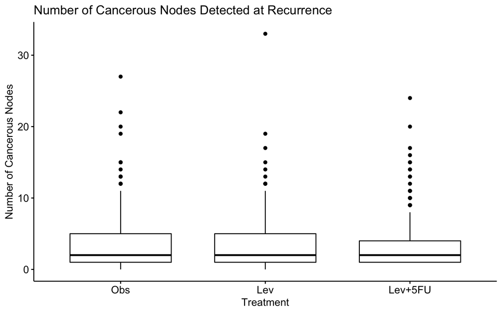

```r
ggboxplot(studyA, x = "rx", y = "nodes",
          #color = "rx", palette = c("#00AFBB", "#E7B800", "#FC4E07"),
          order = c("Obs", "Lev", "Lev+5FU"),
          ylab = "Number of Cancerous Nodes", xlab = "Treatment",
          title = "Number of Cancerous Nodes Detected at Recurrence")
```

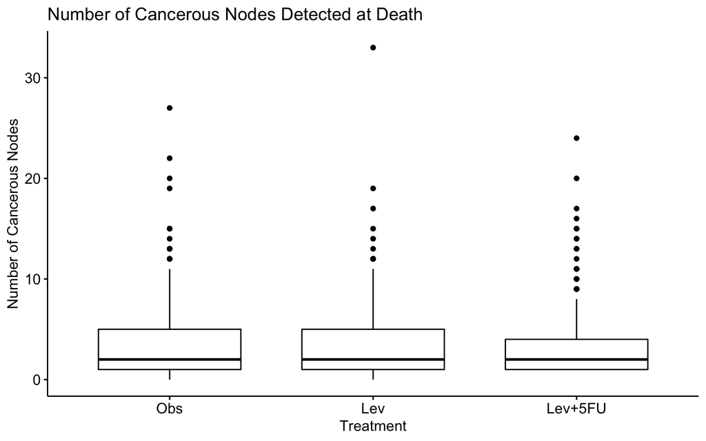

```r
ggboxplot(studyB, x = "rx", y = "nodes",
          #color = "rx", palette = c("#00AFBB", "#E7B800", "#FC4E07"),
          order = c("Obs", "Lev", "Lev+5FU"),
          ylab = "Number of Cancerous Nodes", xlab = "Treatment",
          title = "Number of Cancerous Nodes Detected at Death")
```

Thus, for the analysis, we looked at the discrete quantitative “time” variable (measured in days) on the effect of “status”, to determine the effectiveness of the different treatment types and the Hazard Ratios for each treatment.

# Research Questions

We sought to answer questions about the effectiveness of the different treatment types:

- Which treatment had a lower recurrence rate?
- Which treatment had a greater amount of time until recurrence
- Which treatment had a higher survival rate?
- Which treatment had a higher life expectancy?

# Data Exploration

## Box plots

### Recurrence Data

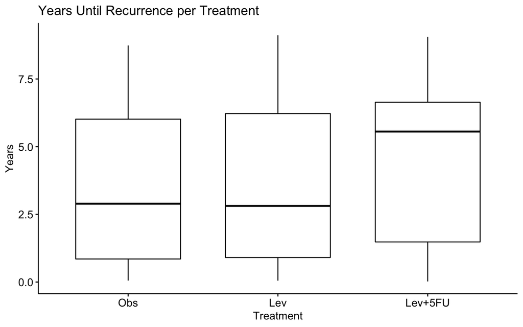

```r
library(ggpubr)
ggboxplot(studyA, x = "rx", y = "years",
          #color = "rx", palette = c("#00AFBB", "#E7B800", "#FC4E07"),
          order = c("Obs", "Lev", "Lev+5FU"),
          ylab = "Years", xlab = "Treatment",
          title = "Years Until Recurrence per Treatment")
```

### Death Data

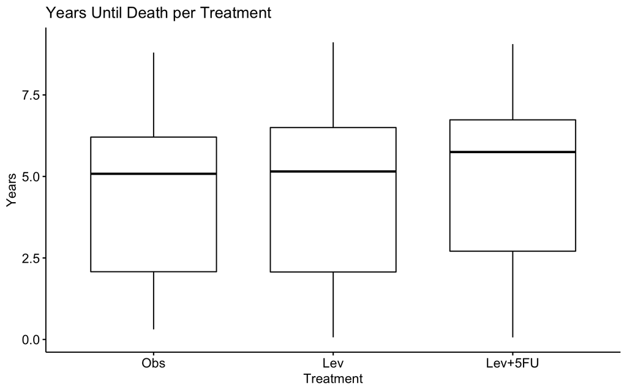

```r
ggboxplot(studyB, x = "rx", y = "years",
          #color = "rx", palette = c("#00AFBB", "#E7B800", "#FC4E07"),
          order = c("Obs", "Lev", "Lev+5FU"),
          ylab = "Years", xlab = "Treatment",
          title = "Years Until Death per Treatment")
```

## Survival Curve (Kaplan-Meier Survival Plot)

### Recurrence data

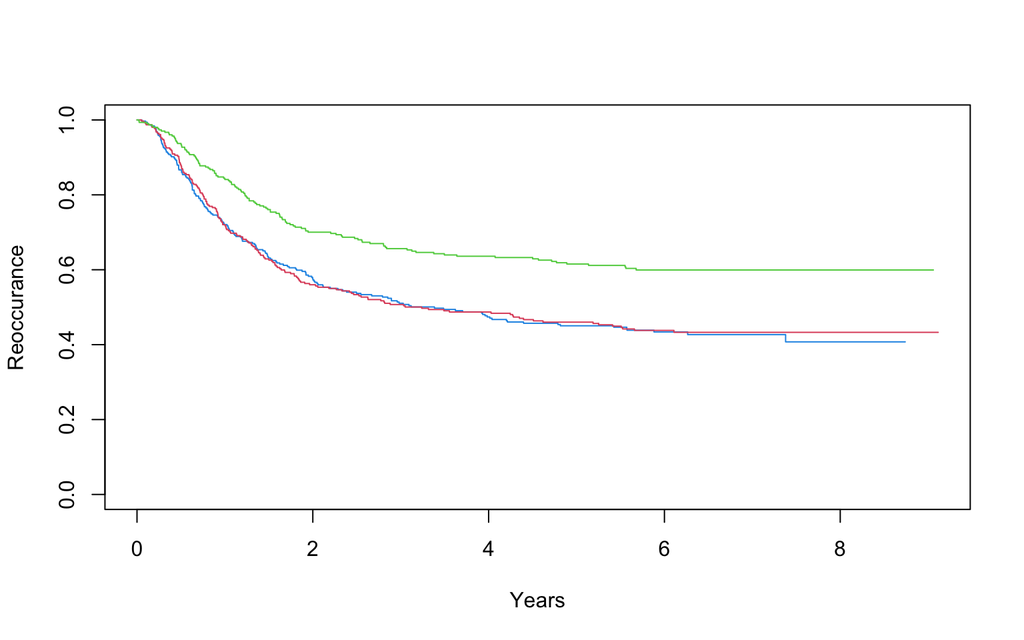

```r
# Kaplan-Meier Survival Plot (Survival Rate Over Time)
library(survival)
library(survminer)
# Survival curve by treatment
plot(survfit(Surv(years, status) ~ xnum, data=studyA),
     ylab= "Reoccurance",
     xlab = "Years",
     title = "Reoccurance Rate by Treatment",
     col = c(4,2,3),)
```

### Survival Data

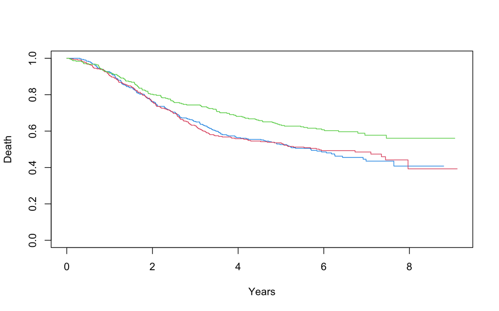

```r
# Kaplan-Meier Survival Plot (Survival Rate Over Time)
library(survival)
library(survminer)
# Survival curve by treatment
plot(survfit(Surv(years, status) ~ xnum, data=studyB),
     ylab= "Death",
     xlab = "Years",
     title = "Death Rate by Treatment",
     col = c(4,2,3)
     )
```

## Survival Curves Detail with Confidence Intervals

### Recurrence Data

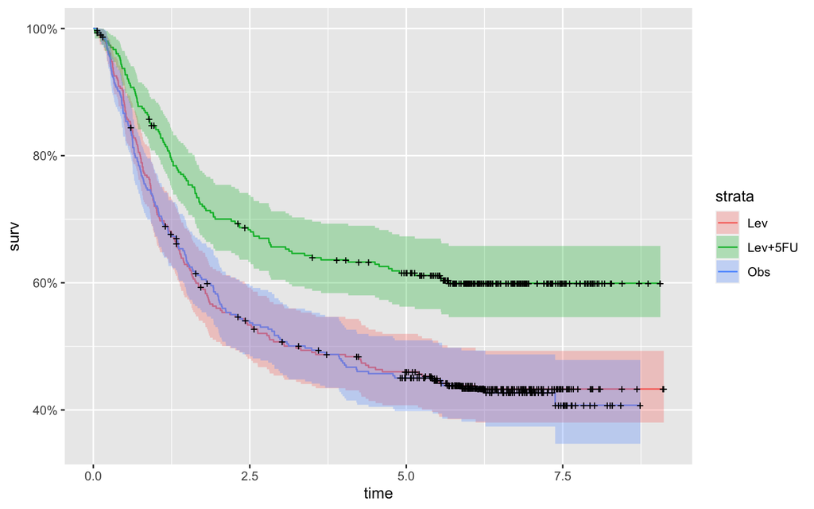

```r
library(ggfortify)
library(survival)
fitA <- survfit(Surv(years, status) ~ rx, data=studyA)
autoplot(fitA)
```

### Death Data

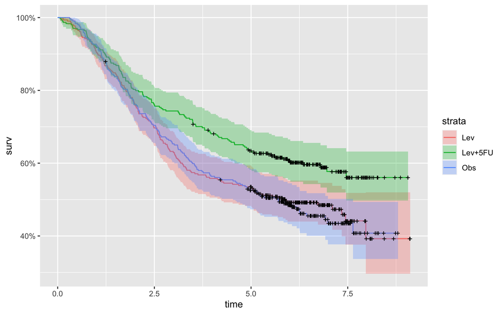

```r
library(ggfortify)
library(survival)
fitB <- survfit(Surv(years, status) ~ rx, data=studyB)
autoplot(fitB)
```

# Data Analysis

## Chi Squared Independence

Provided are the mean summaries and Chi Squared P-values. Sex and status are found to be statistically different between the three treatment groups as their p-value is less than the alpha of 0.05.

```r
library(gtsummary)
trialA <- studyA %>% select(!c(id, xnum, differ, time, etype))
trialA %>%
  tbl_summary(by = rx) %>%
  add_p(test = all_continuous() ~ "t.test") %>%
  modify_caption("Table 3. Reoccurance by Treatment")
```

Table 3. Reoccurance by Treatment

| **Characteristic** | **Lev**, N = 310<sup>1</sup> | **Lev+5FU**, N = 304<sup>1</sup> | **Obs**, N = 315<sup>1</sup> | **p-value**<sup>2</sup> |
| --- | --- | --- | --- | --- |
| study | 310 (100%) | 304 (100%) | 315 (100%) |  |
| sex | 177 (57%) | 141 (46%) | 166 (53%) | 0.028 |
| age | 61 (53, 69) | 62 (52, 70) | 60 (53, 68) |  |
| obstruct | 63 (20%) | 54 (18%) | 63 (20%) | 0.7 |
| perfor | 10 (3.2%) | 8 (2.6%) | 9 (2.9%) | >0.9 |
| adhere | 49 (16%) | 39 (13%) | 47 (15%) | 0.6 |
| nodes | 2 (1, 5) | 2 (1, 4) | 2 (1, 5) |  |
| Unknown | 6 | 9 | 3 |  |
| status | 172 (55%) | 119 (39%) | 177 (56%) | <0.001 |
| extent |  |  |  | 0.3 |
| 1 | 3 (1.0%) | 10 (3.3%) | 8 (2.5%) |  |
| 2 | 36 (12%) | 32 (11%) | 38 (12%) |  |
| 3 | 259 (84%) | 251 (83%) | 249 (79%) |  |
| 4 | 12 (3.9%) | 11 (3.6%) | 20 (6.3%) |  |
| surg | 80 (26%) | 76 (25%) | 91 (29%) | 0.5 |
| node4 | 89 (29%) | 79 (26%) | 87 (28%) | 0.7 |
| years | 2.81 (0.91, 6.22) | 5.56 (1.48, 6.64) | 2.89 (0.85, 6.02) |  |

<sup>1</sup> n (%); Median (IQR)  
<sup>2</sup> Pearson's Chi-squared test

```r
library(gtsummary)
trialB <- studyB %>% select(!c(id, xnum, differ, time, etype))
trialB %>%
  tbl_summary(by = rx) %>%
  add_p(test = all_continuous() ~ "t.test") %>%
  modify_caption("Table 4. Death by Treatment")
```

Table 4. Death by Treatment

| **Characteristic** | **Lev**, N = 310<sup>1</sup> | **Lev+5FU**, N = 304<sup>1</sup> | **Obs**, N = 315<sup>1</sup> | **p-value**<sup>2</sup> |
| --- | --- | --- | --- | --- |
| study | 310 (100%) | 304 (100%) | 315 (100%) |  |
| sex | 177 (57%) | 141 (46%) | 166 (53%) | 0.028 |
| age | 61 (53, 69) | 62 (52, 70) | 60 (53, 68) |  |
| obstruct | 63 (20%) | 54 (18%) | 63 (20%) | 0.7 |
| perfor | 10 (3.2%) | 8 (2.6%) | 9 (2.9%) | >0.9 |
| adhere | 49 (16%) | 39 (13%) | 47 (15%) | 0.6 |
| nodes | 2 (1, 5) | 2 (1, 4) | 2 (1, 5) |  |
| Unknown | 6 | 9 | 3 |  |
| status | 161 (52%) | 123 (40%) | 168 (53%) | 0.002 |
| extent |  |  |  | 0.3 |
| 1 | 3 (1.0%) | 10 (3.3%) | 8 (2.5%) |  |
| 2 | 36 (12%) | 32 (11%) | 38 (12%) |  |
| 3 | 259 (84%) | 251 (83%) | 249 (79%) |  |
| 4 | 12 (3.9%) | 11 (3.6%) | 20 (6.3%) |  |
| surg | 80 (26%) | 76 (25%) | 91 (29%) | 0.5 |
| node4 | 89 (29%) | 79 (26%) | 87 (28%) | 0.7 |
| years | 5.15 (2.07, 6.50) | 5.75 (2.71, 6.74) | 5.08 (2.08, 6.21) |  |

<sup>1</sup> n (%); Median (IQR)  
<sup>2</sup> Pearson's Chi-squared test

## Cox Regression

The Proportional hazards model is a class of survival model. Survival models relate the time that passes, before some event occurs, to one or more covariates that may be associated with that quantity of time. In a proportional hazards model, the unique effect of a unit increase in a covariate is multiplicative in regard to the hazard rate.

The Cox Regression or Proportional-Hazards Model can be estimated as follows:

$$\lambda(t|X) = \lambda_0(t)*\text{exp}(\beta_1 X_1 + \ldots \beta_p X_p)
\\$$

where:

$$\lambda:\text{hazard}
\\
\beta:\text{measure of impact of the covariates}
\\
X:\text{covariates}$$

### Hypothesis

Based on an exploration of the data, we will examine the following hypotheses, for each treatment option:

$$H_0: \beta = 1 \text{ There is no difference between the treatment Hazard Ratio and the control.}
\\
H_A: \beta < 1 \text{ The treatnent Harard Ratio is less than the control.}$$

### Model

The following is the Cox Hazard ratio model. The control group is 0, the single treatment group is 1, and the combined treatment is 2.

```r
library(survival)
coxModelA <- coxph(Surv(time, status) ~ xnum, data=studyA)
summary(coxModelA)
```

```
Call:
coxph(formula = Surv(time, status) ~ xnum, data = studyA)

  n= 929, number of events= 468

          coef exp(coef) se(coef)      z Pr(>|z|)
xnum1 -0.01512   0.98499  0.10708 -0.141    0.888
xnum2 -0.51209   0.59924  0.11863 -4.317 1.58e-05 ***
---
Signif. codes:  0 '***' 0.001 '**' 0.01 '*' 0.05 '.' 0.1 ' ' 1

      exp(coef) exp(-coef) lower .95 upper .95
xnum1    0.9850      1.015    0.7985    1.2150
xnum2    0.5992      1.669    0.4749    0.7561

Concordance= 0.554  (se = 0.013 )
Likelihood ratio test= 24.34  on 2 df,   p=5e-06
Wald test            = 22.58  on 2 df,   p=1e-05
Score (logrank) test = 23.07  on 2 df,   p=1e-05
```

```r
coxModelA %>%
  gtsummary::tbl_regression(exp = TRUE, label = xnum ~ "Treatment") %>%
  modify_caption("Table 5. Reoccurance Cox Regression")
```

Table 5. Reoccurance Cox Regression

| **Characteristic** | **HR**<sup>1</sup> | **95% CI**<sup>1</sup> | **p-value** |
| --- | --- | --- | --- |
| Treatment |  |  |  |
| 0 | — | — |  |
| 1 | 0.98 | 0.80, 1.21 | 0.9 |
| 2 | 0.60 | 0.47, 0.76 | <0.001 |

<sup>1</sup> HR = Hazard Ratio, CI = Confidence Interval

Given the Hazard Ratio of 0.98 for the levamisole treatment, it can be stated that this treatment only resulted in a 2% reduction in the cancer recurrence rate. A p-value of 0.89 for this metric also indicates that the result is not statistically significant, as it is greater than the alpha value of 0.05.

However, given the Hazard Ratio of 0.60 for the levamisole and fluorouracil treatment, it can be stated that this treatment resulted in a 40% reduction in the cancer recurrence rate. A p-value of 1.58e-05 for this metric indicates that the result is statistically significant, as it is less than the alpha value of 0.05.

```r
library(survival)
coxModelB <- coxph(Surv(time, status) ~ xnum, data=studyB)
summary(coxModelA)
```

```
Call:
coxph(formula = Surv(time, status) ~ xnum, data = studyA)

  n= 929, number of events= 468

          coef exp(coef) se(coef)      z Pr(>|z|)
xnum1 -0.01512   0.98499  0.10708 -0.141    0.888
xnum2 -0.51209   0.59924  0.11863 -4.317 1.58e-05 ***
---
Signif. codes:  0 '***' 0.001 '**' 0.01 '*' 0.05 '.' 0.1 ' ' 1

      exp(coef) exp(-coef) lower .95 upper .95
xnum1    0.9850      1.015    0.7985    1.2150
xnum2    0.5992      1.669    0.4749    0.7561

Concordance= 0.554  (se = 0.013 )
Likelihood ratio test= 24.34  on 2 df,   p=5e-06
Wald test            = 22.58  on 2 df,   p=1e-05
Score (logrank) test = 23.07  on 2 df,   p=1e-05
```

```r
coxModelB %>%
  gtsummary::tbl_regression(exp = TRUE, label = list(xnum ~ "Treatment")) %>%
  modify_caption("Table 6. Death Rate Cox Regression")
```

Table 6. Death Rate Cox Regression

| **Characteristic** | **HR**<sup>1</sup> | **95% CI**<sup>1</sup> | **p-value** |
| --- | --- | --- | --- |
| Treatment |  |  |  |
| 0 | — | — |  |
| 1 | 0.97 | 0.78, 1.21 | 0.8 |
| 2 | 0.69 | 0.55, 0.87 | 0.002 |

<sup>1</sup> HR = Hazard Ratio, CI = Confidence Interval

### Test assumptions

It is assumed that treatment groups were randomly distributed within the sample. Assume random censoring of the data (every data point is collected in this study).

Perform the Schoenfeld Individual test to measure for a constant hazard ratio over time. This means that there are no sudden deviations from the survival curve over time. Assumption is met if the data is not significant (P>0.05).

### Recurrence Data

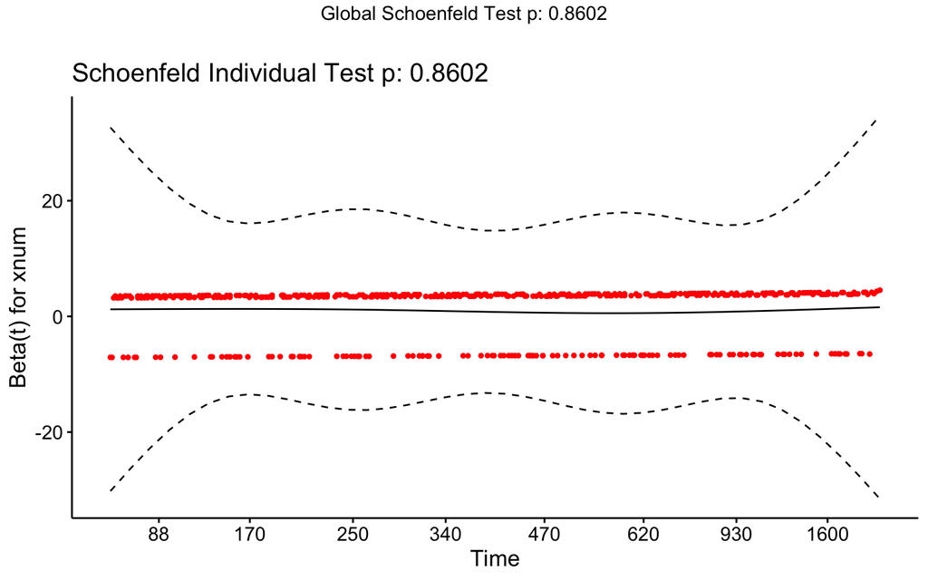

```r
test.ph <- cox.zph(coxModelA)
ggcoxzph(test.ph)
```

### Death Data

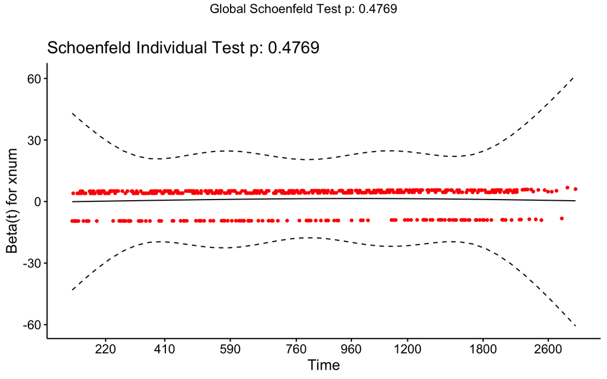

```r
test.phB <- cox.zph(coxModelB)
ggcoxzph(test.phB)
```

Given the Hazard Ratio of 0.97 for the levamisole treatment, it can be stated that this treatment only resulted in a 3% reduction in the cancer death rate. A p-value of 0.80 for this metric also indicates that the result is not statistically significant.

# Conclusions

For future studies, additional combinations of drug therapies could be examined. Since this study was published over 20 years ago, advances in medicine could have led to the creation of new therapies that could be tested in addition to these medications. Additionally, the effects using just the new therapy alone should be tested as well. It is noted that ethical concerns may prevent such an experiment from occurring. Finally, the spread of cancer is an important consideration that should be examined in addition to recurrence and death rates.

To conclude, the well run study provided strong evidence to suggest that the levamisole and fluorouracil treatment can offer a significant difference in recurrence and survival rates compared to the observed and the levamisole alone groups. Using a Cox Regression model, we were able to see a 40% reduction in the Hazard Ratio compared to the control. While these results are promising, future studies into additional single and multiple treatments must be conducted.